# iabp

Wei-Hung Weng

November 4, 2017

# Basic setup

```
## [1] 0
```

# Cohort construction

We loaded the cohort extracted directly using SQL, then the cohort table was joined with other views with SOFA score, Elixhauser score, past history table that associated with our problem, and 30-day mortality information. We also defined platelet drop rate and plate nadir groups here.

```r
basic <- read.csv("../data/iabp_medi.csv", stringsAsFactors = FALSE)
patient_list <- basic[, 'subject_id']

# sofa score (by mmg)
s = dbReadTable(con, "sofa")
s = s[, c(1, 2, 4)]
s = s[s$subject_id %in% patient_list, ]
s = s[!duplicated(s$subject_id, fromLast = TRUE), ]

# elixhauser score (https://raw.githubusercontent.com/MIT-LCP/mimic-code/master/concepts/comorbidity/elixhauser-ahrq-v37-with-drg.sql)
elix = dbReadTable(con, "elixhauser_ahrq_score")
elix = elix[, c(1:3)]
elix = elix[elix$subject_id %in% patient_list, ]
elix = elix[!duplicated(elix$subject_id, fromLast = TRUE), ]

# selected history (from history.sql)
e = dbReadTable(con, "elixhauser_ahrq_no_drg")
e = e[, c(1:7, 11)]
e = e[e$subject_id %in% patient_list, ]
e = e[!duplicated(e$subject_id, fromLast = TRUE), ]

# 30-day mortality
mort = dbGetQuery(con, "select a.subject_id, a.hadm_id, DATE_PART('day', p.dod - a.admittime) AS hosp_surv_days from admissions a  INNER JOIN patients p ON a.subject_id = p.subject_id")
mort = mort[mort$subject_id %in% patient_list, ]
mort$m30 = ifelse(mort$hosp_surv_days >= 30 | is.na(mort$hosp_surv_days), 0, 1)

# table join
basic = merge(basic, e, by=c("subject_id", "hadm_id"), all.x=T)
basic = merge(basic, s, by=c("subject_id", "hadm_id"), all.x=T)
basic = merge(basic, elix, by=c("subject_id", "hadm_id"), all.x=T)
basic = merge(basic, mort, by=c("subject_id", "hadm_id"), all.x=T)
for (i in 25:37) {
  basic[, i] = ifelse(is.na(basic[, i]), 0, basic[, i]) # problematic
}
for(i in c(15,17,23,24,38,39)){
  basic[, i] = ifelse(is.na(basic[, i]), mean(basic[, i], na.rm = TRUE), basic[, i]) # problematic
}

# define platelet drop rate
basic$plt_drop = (basic$plt - basic$plt_minvalue) / basic$plt
basic$plt_drop_grp <- cut2(basic$plt_drop, c(0.2, 0.4, 0.6, 0.8))

basic$plt_nadir = cut2(basic$plt_minvalue, c(20, 50, 100))
basic$plt_nadir = factor(basic$plt_nadir, levels=rev(levels(basic$plt_nadir)))
#write.csv(basic, "../data/iabp.csv")
```

We planned to extract surgical history features form notes but discarded this idea since there were only five patients with narative information of surgery in the texts.

# Figure 1: Cohort selection

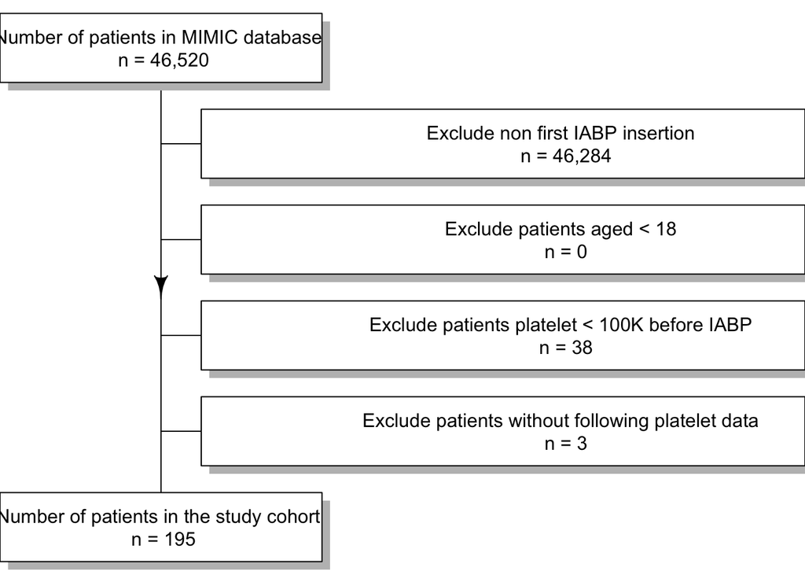

```r
par(mfrow = c(1, 1))
par(mar = c(0, 0, 0, 0))
openplotmat()

num_of_boxes <- 6
auto_coords = coordinates(num_of_boxes)
vert_pos = rev(auto_coords[,1])
box_pos <- matrix(nrow = num_of_boxes, ncol = 2, data = 0)
box_pos[1,] = c(0.20, vert_pos[1])
for (i in 2:(num_of_boxes-1)) {
  box_pos[i,] = c(0.70, vert_pos[i])
}
box_pos[num_of_boxes,] = c(0.20, vert_pos[num_of_boxes])

# Add the box content
box_content <- matrix(nrow = num_of_boxes, ncol = 1, data = 0)
box_content[1] = paste("Number of patients in MIMIC database \n n = 46,520")
box_content[2] = paste("Exclude non first IABP insertion \n n = 46,284")
box_content[3] = paste("Exclude patients aged < 18 \n n = 0")
box_content[4] = paste("Exclude patients platelet < 100K before IABP \n n = 38")
box_content[5] = paste("Exclude patients without following platelet data \n n = 3")
box_content[num_of_boxes] = paste("Number of patients in the study cohort \n n = 195")

# Adjust the size of boxes to fit content
box_x <- c(0.20, rep(0.45, num_of_boxes-2), 0.20)
box_y <- rep(0.06, num_of_boxes)

# Draw the arrows
for (i in 2:(num_of_boxes-1)) {
  straightarrow(from = c(box_pos[1,1],box_pos[i,2]), to = box_pos[i,], lwd = 1)
}
straightarrow(from = box_pos[1,], to = box_pos[num_of_boxes,], lwd = 1)

# Draw the boxes
for (i in 1:num_of_boxes) {
  textrect(mid = box_pos[i,], radx = box_x[i], rady = box_y[i],
           lab = box_content[i],
           shadow.col = "grey")
}
```

# Table 1a: Baseline characteristics of the selected cohort (drop)

```r
CreateTableOne(vars=c("age", "gender", "bmi", "plt", "plt_minvalue", "plt_drop", "ckmb", "hct", "hb", "rbc", "cre", "pt", "ptt",
                      "wbc", "neutrophil", "tempc", "bivalirudin", "heparin", "asprin", "lmwh", "glycoprotein", "adp", "thrombolytic",
                      "cad", "stroke", "hemorrhage", "thrombosis", "congestive_heart_failure", "peripheral_vascular",
                      "los_hospital", "los_icu", "hospital_expire_flag", "m30", "iabp_time"),
               strata=c("plt_drop_grp"),
               data=basic, test=TRUE) %>% print(
                 printToggle      = FALSE,
                 showAllLevels    = TRUE,
                 cramVars         = "kon"
               ) %>% {data.frame(
                 variable_name    = gsub(" ", "&nbsp;", rownames(.), fixed = TRUE), .,
                 row.names        = NULL,
                 check.names      = FALSE,
                 stringsAsFactors = FALSE)} %>% knitr::kable()
```

| variable_name | level | [-0.323, 0.200) | [ 0.200, 0.400) | [ 0.400, 0.600) | [ 0.600, 0.800) | [ 0.800, 0.976] | p | test |
| --- | --- | --- | --- | --- | --- | --- | --- | --- |
| n |  | 20 | 41 | 82 | 41 | 11 |  |  |
| age (mean (sd)) |  | 80.71 (52.51) | 83.62 (50.76) | 71.80 (27.97) | 71.18 (12.57) | 67.72 (12.28) | 0.313 |  |
| gender (%) | F | 6 (30.0) | 7 (17.1) | 27 (32.9) | 17 (41.5) | 6 (54.5) | 0.076 |  |
|  | M | 14 (70.0) | 34 (82.9) | 55 (67.1) | 24 (58.5) | 5 (45.5) |  |  |
| bmi (mean (sd)) |  | 35.53 (34.20) | 27.93 (5.05) | 28.96 (5.64) | 28.17 (5.17) | 29.01 (7.65) | 0.181 |  |
| plt (mean (sd)) |  | 224.60 (85.23) | 208.29 (67.29) | 224.17 (76.01) | 239.59 (90.04) | 206.00 (68.32) | 0.429 |  |
| plt_minvalue (mean (sd)) |  | 206.80 (79.61) | 144.02 (45.06) | 113.66 (37.97) | 72.90 (33.67) | 28.36 (11.89) | <0.001 |  |
| plt_drop (mean (sd)) |  | 0.07 (0.13) | 0.30 (0.07) | 0.49 (0.05) | 0.70 (0.06) | 0.86 (0.05) | <0.001 |  |
| ckmb (mean (sd)) |  | 9.76 (8.47) | 6.00 (2.97) | 7.43 (13.23) | 6.50 (4.87) | 6.29 (2.20) | 0.647 |  |
| hct (mean (sd)) |  | 33.26 (4.23) | 31.49 (4.88) | 29.77 (3.72) | 31.08 (4.35) | 29.10 (4.27) | 0.006 |  |
| hb (mean (sd)) |  | 11.07 (1.46) | 10.56 (1.66) | 9.94 (1.29) | 10.33 (1.57) | 9.76 (1.57) | 0.013 |  |
| rbc (mean (sd)) |  | 3.70 (0.46) | 3.44 (0.53) | 3.35 (0.45) | 3.42 (0.57) | 3.23 (0.49) | 0.054 |  |
| cre (mean (sd)) |  | 1.45 (0.95) | 1.26 (0.59) | 1.61 (1.45) | 1.51 (0.89) | 1.45 (0.67) | 0.600 |  |
| pt (mean (sd)) |  | 18.70 (10.87) | 16.29 (5.21) | 16.29 (4.89) | 20.43 (12.00) | 27.35 (21.66) | 0.001 |  |
| ptt (mean (sd)) |  | 46.70 (24.14) | 36.35 (15.05) | 37.77 (20.82) | 41.28 (23.07) | 57.22 (43.38) | 0.039 |  |
| wbc (mean (sd)) |  | 11.93 (5.87) | 9.76 (3.38) | 10.59 (3.91) | 12.93 (5.02) | 15.45 (6.79) | <0.001 |  |
| neutrophil (mean (sd)) |  | 80.29 (9.20) | 79.21 (10.46) | 78.25 (9.43) | 78.09 (11.53) | 82.41 (7.97) | 0.668 |  |
| tempc (mean (sd)) |  | 49.02 (4.00) | 50.62 (14.99) | 51.90 (17.46) | 48.72 (15.47) | 45.66 (6.46) | 0.639 |  |
| bivalirudin (mean (sd)) |  | 0.05 (0.22) | 0.00 (0.00) | 0.00 (0.00) | 0.02 (0.16) | 0.00 (0.00) | 0.261 |  |
| heparin (mean (sd)) |  | 0.70 (0.47) | 0.71 (0.46) | 0.84 (0.37) | 0.90 (0.30) | 0.91 (0.30) | 0.091 |  |
| asprin (mean (sd)) |  | 0.00 (0.00) | 0.00 (0.00) | 0.00 (0.00) | 0.00 (0.00) | 0.00 (0.00) | NaN |  |
| lmwh (mean (sd)) |  | 0.00 (0.00) | 0.05 (0.22) | 0.04 (0.19) | 0.07 (0.26) | 0.09 (0.30) | 0.682 |  |
| glycoprotein (mean (sd)) |  | 0.20 (0.41) | 0.07 (0.26) | 0.07 (0.26) | 0.07 (0.26) | 0.00 (0.00) | 0.307 |  |
| adp (mean (sd)) |  | 0.00 (0.00) | 0.00 (0.00) | 0.00 (0.00) | 0.00 (0.00) | 0.09 (0.30) | 0.002 |  |
| thrombolytic (mean (sd)) |  | 0.00 (0.00) | 0.00 (0.00) | 0.00 (0.00) | 0.00 (0.00) | 0.00 (0.00) | NaN |  |
| cad (mean (sd)) |  | 0.45 (0.51) | 0.44 (0.50) | 0.37 (0.48) | 0.24 (0.43) | 0.18 (0.40) | 0.221 |  |
| stroke (mean (sd)) |  | 0.10 (0.31) | 0.05 (0.22) | 0.04 (0.19) | 0.05 (0.22) | 0.00 (0.00) | 0.735 |  |
| hemorrhage (mean (sd)) |  | 0.00 (0.00) | 0.02 (0.16) | 0.04 (0.19) | 0.02 (0.16) | 0.00 (0.00) | 0.879 |  |
| thrombosis (mean (sd)) |  | 0.00 (0.00) | 0.02 (0.16) | 0.02 (0.16) | 0.05 (0.22) | 0.00 (0.00) | 0.795 |  |
| congestive_heart_failure (mean (sd)) |  | 0.50 (0.51) | 0.32 (0.47) | 0.43 (0.50) | 0.59 (0.50) | 0.45 (0.52) | 0.177 |  |
| peripheral_vascular (mean (sd)) |  | 0.10 (0.31) | 0.12 (0.33) | 0.15 (0.36) | 0.17 (0.38) | 0.27 (0.47) | 0.723 |  |
| los_hospital (mean (sd)) |  | 6.79 (5.05) | 7.94 (4.72) | 13.45 (12.51) | 12.90 (8.41) | 16.55 (8.69) | 0.002 |  |
| los_icu (mean (sd)) |  | 3.99 (3.87) | 4.90 (4.63) | 8.58 (9.78) | 9.36 (8.22) | 12.93 (8.19) | 0.003 |  |
| hospital_expire_flag (mean (sd)) |  | 0.15 (0.37) | 0.12 (0.33) | 0.13 (0.34) | 0.29 (0.46) | 0.45 (0.52) | 0.024 |  |
| m30 (mean (sd)) |  | 0.20 (0.41) | 0.12 (0.33) | 0.15 (0.36) | 0.29 (0.46) | 0.45 (0.52) | 0.042 |  |
| iabp_time (mean (sd)) |  | 1133.70 (582.75) | 1782.61 (1786.81) | 2628.16 (2524.64) | 2814.20 (1829.01) | 2940.64 (2061.63) | 0.008 |  |

# Table 1b: Baseline characteristics of the selected cohort (nadir)

```r
CreateTableOne(vars=c("age", "gender", "bmi", "plt", "plt_minvalue", "plt_drop", "ckmb", "hct", "hb", "rbc", "cre", "pt", "ptt",
                      "wbc", "neutrophil", "tempc", "bivalirudin", "heparin", "asprin", "lmwh", "glycoprotein", "adp", "thrombolytic",
                      "cad", "stroke", "hemorrhage", "thrombosis", "congestive_heart_failure", "peripheral_vascular",
                      "los_hospital", "los_icu", "hospital_expire_flag", "m30", "iabp_time"),
               strata=c("plt_nadir"),
               data=basic, test=TRUE) %>% print(
                 printToggle      = FALSE,
                 showAllLevels    = TRUE,
                 cramVars         = "kon"
               ) %>% {data.frame(
                 variable_name    = gsub(" ", "&nbsp;", rownames(.), fixed = TRUE), .,
                 row.names        = NULL,
                 check.names      = FALSE,
                 stringsAsFactors = FALSE)} %>% knitr::kable()
```

| variable_name | level | [100,394] | [ 50,100) | [ 20, 50) | [ 5, 20) | p | test |
| --- | --- | --- | --- | --- | --- | --- | --- |
| n |  | 120 | 53 | 20 | 2 |  |  |
| age (mean (sd)) |  | 74.25 (38.08) | 76.69 (33.06) | 73.36 (11.83) | 76.08 (3.82) | 0.974 |  |
| gender (%) | F | 33 (27.5) | 17 (32.1) | 12 (60.0) | 1 (50.0) | 0.036 |  |
|  | M | 87 (72.5) | 36 (67.9) | 8 (40.0) | 1 (50.0) |  |  |
| bmi (mean (sd)) |  | 29.88 (14.75) | 28.01 (5.63) | 28.58 (5.29) | 31.54 (13.11) | 0.800 |  |
| plt (mean (sd)) |  | 252.12 (75.71) | 179.49 (58.16) | 169.95 (54.28) | 168.00 (56.57) | <0.001 |  |
| plt_minvalue (mean (sd)) |  | 151.36 (50.52) | 70.92 (13.66) | 35.85 (9.87) | 11.50 (9.19) | <0.001 |  |
| plt_drop (mean (sd)) |  | 0.37 (0.18) | 0.57 (0.13) | 0.77 (0.08) | 0.92 (0.08) | <0.001 |  |
| ckmb (mean (sd)) |  | 7.28 (11.51) | 7.22 (4.66) | 5.79 (3.09) | 7.11 (0.00) | 0.933 |  |
| hct (mean (sd)) |  | 31.16 (4.36) | 30.43 (4.34) | 28.93 (3.61) | 30.75 (5.44) | 0.180 |  |
| hb (mean (sd)) |  | 10.40 (1.51) | 10.16 (1.50) | 9.75 (1.32) | 10.00 (2.26) | 0.311 |  |
| rbc (mean (sd)) |  | 3.48 (0.51) | 3.34 (0.50) | 3.21 (0.44) | 3.44 (0.76) | 0.086 |  |
| cre (mean (sd)) |  | 1.31 (0.86) | 1.74 (1.56) | 1.91 (0.95) | 1.60 (0.71) | 0.037 |  |
| pt (mean (sd)) |  | 16.69 (6.63) | 18.24 (9.85) | 24.75 (17.36) | 26.20 (6.65) | 0.002 |  |
| ptt (mean (sd)) |  | 39.30 (21.13) | 34.75 (12.84) | 61.21 (38.48) | 30.55 (1.91) | <0.001 |  |
| wbc (mean (sd)) |  | 10.56 (3.74) | 11.48 (5.06) | 15.06 (6.81) | 14.95 (3.75) | 0.001 |  |
| neutrophil (mean (sd)) |  | 78.86 (9.96) | 77.77 (9.85) | 81.46 (10.99) | 82.13 (4.62) | 0.536 |  |
| tempc (mean (sd)) |  | 49.96 (15.15) | 51.44 (14.56) | 50.14 (17.74) | 43.86 (9.13) | 0.870 |  |
| bivalirudin (mean (sd)) |  | 0.01 (0.09) | 0.00 (0.00) | 0.05 (0.22) | 0.00 (0.00) | 0.296 |  |
| heparin (mean (sd)) |  | 0.80 (0.40) | 0.79 (0.41) | 0.95 (0.22) | 1.00 (0.00) | 0.361 |  |
| asprin (mean (sd)) |  | 0.00 (0.00) | 0.00 (0.00) | 0.00 (0.00) | 0.00 (0.00) | NaN |  |
| lmwh (mean (sd)) |  | 0.05 (0.22) | 0.02 (0.14) | 0.10 (0.31) | 0.00 (0.00) | 0.508 |  |
| glycoprotein (mean (sd)) |  | 0.11 (0.31) | 0.04 (0.19) | 0.05 (0.22) | 0.00 (0.00) | 0.407 |  |
| adp (mean (sd)) |  | 0.00 (0.00) | 0.00 (0.00) | 0.05 (0.22) | 0.00 (0.00) | 0.032 |  |
| thrombolytic (mean (sd)) |  | 0.00 (0.00) | 0.00 (0.00) | 0.00 (0.00) | 0.00 (0.00) | NaN |  |
| cad (mean (sd)) |  | 0.37 (0.48) | 0.36 (0.48) | 0.30 (0.47) | 0.00 (0.00) | 0.701 |  |
| stroke (mean (sd)) |  | 0.06 (0.24) | 0.04 (0.19) | 0.00 (0.00) | 0.00 (0.00) | 0.675 |  |
| hemorrhage (mean (sd)) |  | 0.02 (0.13) | 0.06 (0.23) | 0.00 (0.00) | 0.00 (0.00) | 0.396 |  |
| thrombosis (mean (sd)) |  | 0.02 (0.13) | 0.06 (0.23) | 0.00 (0.00) | 0.00 (0.00) | 0.396 |  |
| congestive_heart_failure (mean (sd)) |  | 0.43 (0.50) | 0.42 (0.50) | 0.65 (0.49) | 0.00 (0.00) | 0.155 |  |
| peripheral_vascular (mean (sd)) |  | 0.14 (0.35) | 0.09 (0.30) | 0.35 (0.49) | 0.00 (0.00) | 0.045 |  |
| los_hospital (mean (sd)) |  | 9.64 (7.44) | 14.30 (13.28) | 15.85 (9.68) | 21.58 (17.34) | 0.002 |  |
| los_icu (mean (sd)) |  | 6.29 (7.23) | 8.65 (9.06) | 12.74 (8.58) | 21.24 (17.00) | 0.001 |  |
| hospital_expire_flag (mean (sd)) |  | 0.12 (0.32) | 0.19 (0.39) | 0.55 (0.51) | 0.50 (0.71) | <0.001 |  |
| m30 (mean (sd)) |  | 0.14 (0.35) | 0.17 (0.38) | 0.55 (0.51) | 0.50 (0.71) | <0.001 |  |
| iabp_time (mean (sd)) |  | 2109.80 (1872.47) | 2465.47 (2551.54) | 3371.20 (2085.21) | 3864.50 (4134.45) | 0.064 |  |

# Figure 2a: Mortality rate in different groups (drop)

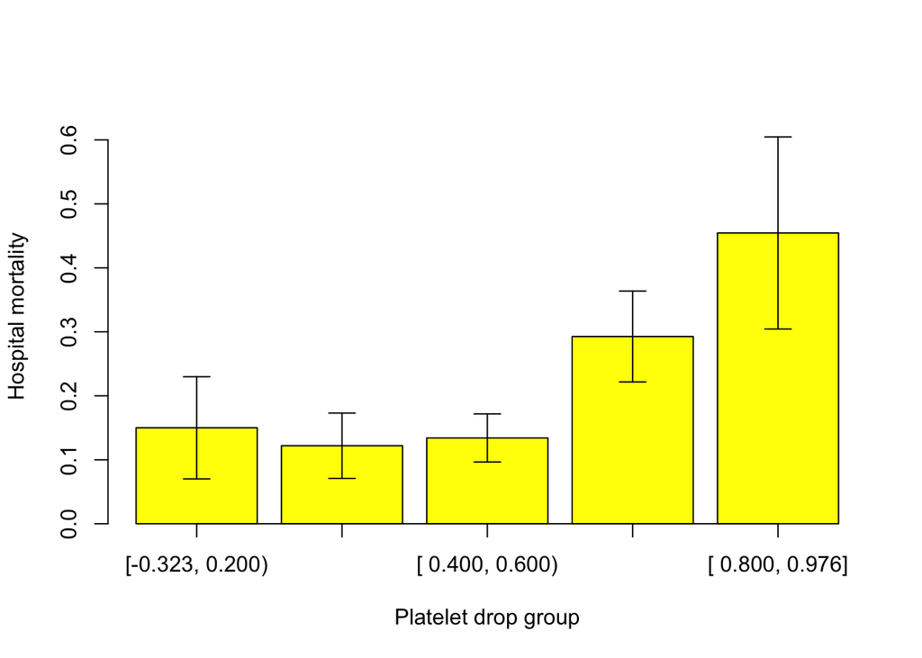

```r
plt_sum <- basic %>% filter(!is.na(plt_drop_grp)) %>%
  group_by(plt_drop_grp) %>%
  dplyr::summarise(n=n(), medianHospLOS=median(los_hospital,na.rm=T),
                   mortHospRate=mean(hospital_expire_flag), mortHospSE=sqrt(mortHospRate*(1-mortHospRate)/n))

error.bar <- function(x, y, upper, lower=upper, length=0.1,...){
  if(length(x) != length(y) | length(y) !=length(lower) | length(lower) != length(upper))
  stop("vectors must be same length")
  arrows(x,y+upper, x, y-lower, angle=90, code=3, length=length, ...)
}

barx <- barplot(plt_sum$mortHospRate, names.arg=plt_sum$plt_drop_grp, ylim=c(0,0.65), col="yellow", axis.lty=1, xlab="Platelet drop group", ylab="Hospital mortality")
error.bar(barx, plt_sum$mortHospRate, plt_sum$mortHospSE)
```

# Figure 2b: Mortality rate in different groups (nadir)

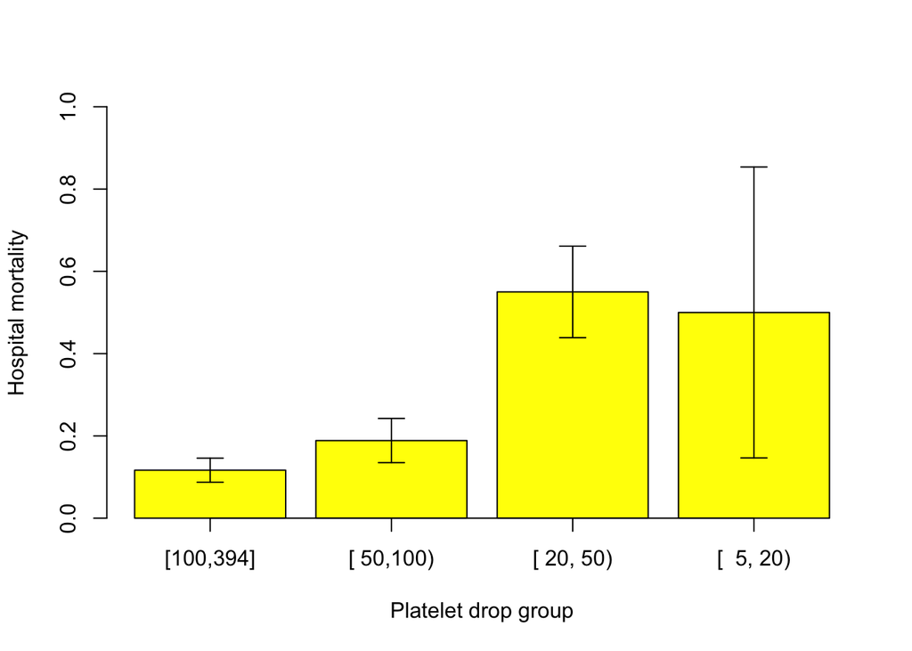

```r
plt_sum <- basic %>% filter(!is.na(plt_nadir)) %>%
  group_by(plt_nadir) %>%
  dplyr::summarise(n=n(), medianHospLOS=median(los_hospital,na.rm=T),
                   mortHospRate=mean(hospital_expire_flag), mortHospSE=sqrt(mortHospRate*(1-mortHospRate)/n))

error.bar <- function(x, y, upper, lower=upper, length=0.1,...){
  if(length(x) != length(y) | length(y) !=length(lower) | length(lower) != length(upper))
  stop("vectors must be same length")
  arrows(x,y+upper, x, y-lower, angle=90, code=3, length=length, ...)
}

barx <- barplot(plt_sum$mortHospRate, names.arg=plt_sum$plt_nadir, ylim=c(0,1), col="yellow", axis.lty=1, xlab="Platelet drop group", ylab="Hospital mortality")
error.bar(barx, plt_sum$mortHospRate, plt_sum$mortHospSE)
```

# Modeling: hospital mortality as the outcome variable (drop)

We applied multivariate logistic regression to calculate the odds ratios of features. Since we have limited patiens in our cohort, it doesn’t make sense to include too many variables for modeling. This we either use LASSO or stepwise selection to reduce the feature number.

```r
basic$plt_drop_grp <- as.factor(ifelse(is.na(basic$plt_drop_grp), 0, basic$plt_drop_grp))

# # using all features won't work
# mdl <- glm(hospital_expire_flag ~ (gender+age+bmi+sofa+elixhauser_vanwalraven+plt_minvalue+plt+ckmb+hct+rbc+hb+cre+pt+ptt+wbc+neutrophil+tempc+bivalirudin+heparin+asprin+lmwh+glycoprotein+adp+thrombolytic+cad+stroke+hemorrhage+thrombosis+congestive_heart_failure+peripheral_vascular+plt_drop_grp),
#                 data=basic[!is.na(basic$plt_drop_grp), ],
#                 family='binomial')


# using features with smaller p-value between groups
mdl <- glm(hospital_expire_flag ~ (age+gender+bmi+cad+pt+wbc+plt_drop_grp),
           data=basic[!is.na(basic$plt_drop_grp), ],
           family='binomial')
summary(mdl)
```

```
##
## Call:
## glm(formula = hospital_expire_flag ~ (age + gender + bmi + cad +
##     pt + wbc + plt_drop_grp), family = "binomial", data = basic[!is.na(basic$plt_drop_grp),
##     ])
##
## Deviance Residuals:
##      Min        1Q    Median        3Q       Max
## -2.08012  -0.37942  -0.18451  -0.05154   2.49932
##
## Coefficients:
##                 Estimate Std. Error z value Pr(>|z|)
## (Intercept)   -13.352465   3.524761  -3.788 0.000152 ***
## age             0.020900   0.007298   2.864 0.004185 **
## genderM        -0.164378   0.644161  -0.255 0.798583
## bmi            -0.095492   0.054652  -1.747 0.080588 .
## cad            -0.095638   0.612696  -0.156 0.875960
## pt              0.133595   0.049830   2.681 0.007339 **
## wbc             0.535198   0.103685   5.162 2.45e-07 ***
## plt_drop_grp2   3.838354   1.902527   2.018 0.043643 *
## plt_drop_grp3   3.879141   1.882850   2.060 0.039375 *
## plt_drop_grp4   4.252513   1.914069   2.222 0.026303 *
## plt_drop_grp5   3.514944   2.021229   1.739 0.082032 .
## ---
## Signif. codes:  0 '***' 0.001 '**' 0.01 '*' 0.05 '.' 0.1 ' ' 1
##
## (Dispersion parameter for binomial family taken to be 1)
##
##     Null deviance: 186.545  on 194  degrees of freedom
## Residual deviance:  88.725  on 184  degrees of freedom
## AIC: 110.72
##
## Number of Fisher Scoring iterations: 7
```

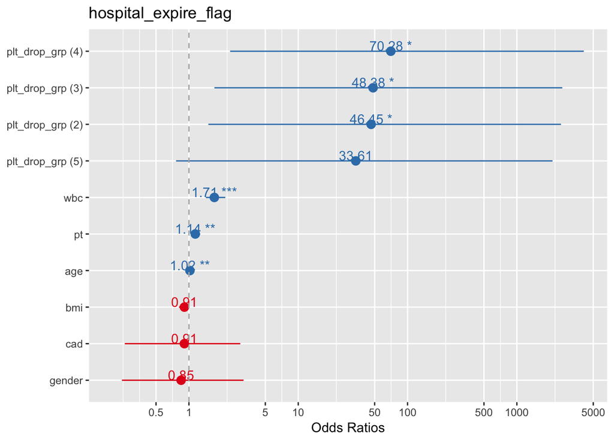

```r
sjp.glm(mdl, sort.est=T)
```

```r
# using features empirically important
mdl <- glm(hospital_expire_flag ~ (age+gender+sofa+elixhauser_vanwalraven+plt_drop_grp),
           data=basic[!is.na(basic$plt_drop_grp), ],
           family='binomial')
summary(mdl)
```

```
##
## Call:
## glm(formula = hospital_expire_flag ~ (age + gender + sofa + elixhauser_vanwalraven +
##     plt_drop_grp), family = "binomial", data = basic[!is.na(basic$plt_drop_grp),
##     ])
##
## Deviance Residuals:
##     Min       1Q   Median       3Q      Max
## -1.7463  -0.5149  -0.3657  -0.2241   2.2809
##
## Coefficients:
##                         Estimate Std. Error z value Pr(>|z|)
## (Intercept)            -4.784865   1.079551  -4.432 9.32e-06 ***
## age                     0.014207   0.004968   2.860 0.004242 **
## genderM                -0.116694   0.460375  -0.253 0.799901
## sofa                    0.172728   0.066554   2.595 0.009450 **
## elixhauser_vanwalraven  0.126027   0.035578   3.542 0.000397 ***
## plt_drop_grp2          -0.076012   0.925915  -0.082 0.934572
## plt_drop_grp3           0.048896   0.822856   0.059 0.952615
## plt_drop_grp4           0.891383   0.841277   1.060 0.289345
## plt_drop_grp5           1.509785   0.993929   1.519 0.128761
## ---
## Signif. codes:  0 '***' 0.001 '**' 0.01 '*' 0.05 '.' 0.1 ' ' 1
##
## (Dispersion parameter for binomial family taken to be 1)
##
##     Null deviance: 186.54  on 194  degrees of freedom
## Residual deviance: 141.43  on 186  degrees of freedom
## AIC: 159.43
##
## Number of Fisher Scoring iterations: 5
```

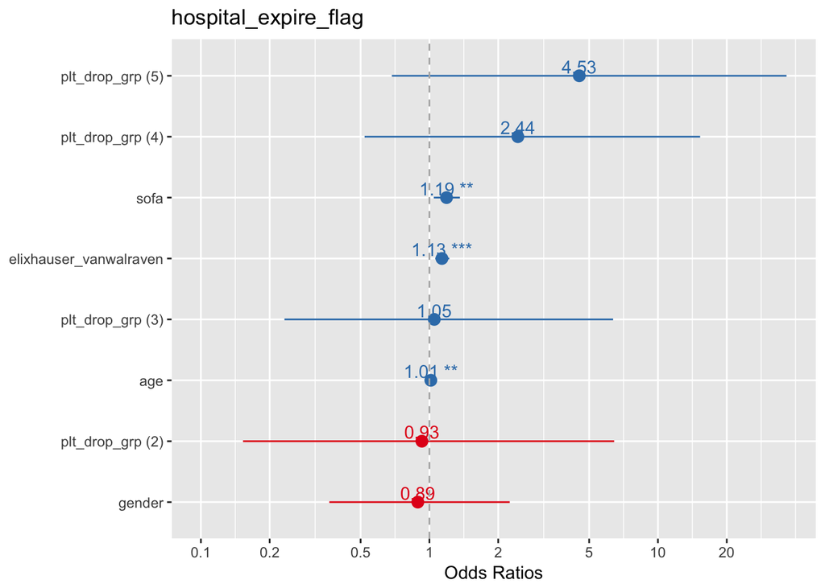

```r
sjp.glm(mdl, sort.est=T)
```

```r
# using LASSO to preselect features
X <- model.matrix(hospital_expire_flag~gender+age+bmi+sofa+elixhauser_vanwalraven+plt_minvalue+plt+ckmb+hct+rbc+hb+cre+pt+ptt+wbc+neutrophil+tempc+bivalirudin+heparin+asprin+lmwh+glycoprotein+adp+thrombolytic+cad+stroke+hemorrhage+thrombosis+congestive_heart_failure+peripheral_vascular+plt_drop_grp, data = basic)
y <- basic[, 9] # 9 for hosp mort, 41 for m30
mdl <- cv.glmnet(X, y, family = "binomial", alpha = 1)
coef(mdl, s=mdl$lambda.1se)
```

```
## 36 x 1 sparse Matrix of class "dgCMatrix"
##                                    1
## (Intercept)              -4.94605198
## (Intercept)               .
## genderM                   .
## age                       .
## bmi                       .
## sofa                      .
## elixhauser_vanwalraven    0.03477862
## plt_minvalue              .
## plt                       .
## ckmb                      .
## hct                       .
## rbc                       .
## hb                        .
## cre                       0.17630497
## pt                        .
## ptt                       0.01393370
## wbc                       0.19061363
## neutrophil                .
## tempc                     .
## bivalirudin               .
## heparin                   .
## asprin                    .
## lmwh                      .
## glycoprotein              .
## adp                       .
## thrombolytic              .
## cad                       .
## stroke                    .
## hemorrhage                .
## thrombosis                .
## congestive_heart_failure  .
## peripheral_vascular       .
## plt_drop_grp2             .
## plt_drop_grp3             .
## plt_drop_grp4             .
## plt_drop_grp5             .
```

```r
mdl <- glm(m30 ~ (cre+ptt+wbc+plt_drop_grp),
           data=basic[!is.na(basic$plt_drop_grp), ],
           family='binomial')
summary(mdl)
```

```
##
## Call:
## glm(formula = m30 ~ (cre + ptt + wbc + plt_drop_grp), family = "binomial",
##     data = basic[!is.na(basic$plt_drop_grp), ])
##
## Deviance Residuals:
##     Min       1Q   Median       3Q      Max
## -1.7816  -0.3494  -0.1945  -0.0876   2.8710
##
## Coefficients:
##                Estimate Std. Error z value Pr(>|z|)
## (Intercept)   -10.69840    1.95102  -5.483 4.17e-08 ***
## cre             0.71644    0.20684   3.464 0.000533 ***
## ptt             0.04394    0.01214   3.619 0.000295 ***
## wbc             0.41032    0.08656   4.740 2.13e-06 ***
## plt_drop_grp2   1.28796    1.26340   1.019 0.307994
## plt_drop_grp3   0.53126    1.17136   0.454 0.650160
## plt_drop_grp4   1.41177    1.21068   1.166 0.243574
## plt_drop_grp5   1.21955    1.53465   0.795 0.426804
## ---
## Signif. codes:  0 '***' 0.001 '**' 0.01 '*' 0.05 '.' 0.1 ' ' 1
##
## (Dispersion parameter for binomial family taken to be 1)
##
##     Null deviance: 192.352  on 194  degrees of freedom
## Residual deviance:  89.952  on 187  degrees of freedom
## AIC: 105.95
##
## Number of Fisher Scoring iterations: 6
```

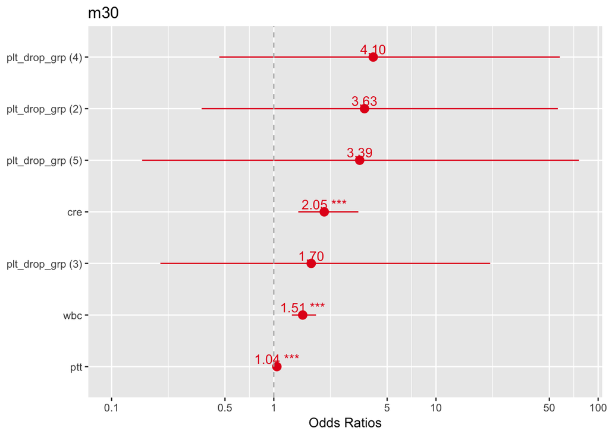

```r
sjp.glm(mdl, sort.est=T)
```

# Modeling: hospital mortality as the outcome variable (nadir)

Do it again for platelet nadir.

```r
basic$plt_nadir <- as.factor(ifelse(is.na(basic$plt_nadir), 0, basic$plt_nadir))

# # using all features won't work
# mdl <- glm(hospital_expire_flag ~ (gender+age+bmi+sofa+elixhauser_vanwalraven+plt_minvalue+plt+ckmb+hct+rbc+hb+cre+pt+ptt+wbc+neutrophil+tempc+bivalirudin+heparin+asprin+lmwh+glycoprotein+adp+thrombolytic+cad+stroke+hemorrhage+thrombosis+congestive_heart_failure+peripheral_vascular+plt_nadir),
#                 data=basic[!is.na(basic$plt_nadir), ],
#                 family='binomial')


# using features with smaller p-value between groups
mdl <- glm(hospital_expire_flag ~ (age+gender+bmi+cad+pt+wbc+plt_nadir),
           data=basic[!is.na(basic$plt_nadir), ],
           family='binomial')
summary(mdl)
```

```
##
## Call:
## glm(formula = hospital_expire_flag ~ (age + gender + bmi + cad +
##     pt + wbc + plt_nadir), family = "binomial", data = basic[!is.na(basic$plt_nadir),
##     ])
##
## Deviance Residuals:
##      Min        1Q    Median        3Q       Max
## -2.94031  -0.40754  -0.22337  -0.09592   2.46946
##
## Coefficients:
##              Estimate Std. Error z value Pr(>|z|)
## (Intercept) -8.133185   2.250551  -3.614 0.000302 ***
## age          0.017446   0.007269   2.400 0.016387 *
## genderM     -0.111805   0.623178  -0.179 0.857615
## bmi         -0.095401   0.053252  -1.791 0.073214 .
## cad         -0.163490   0.630451  -0.259 0.795386
## pt           0.110237   0.050727   2.173 0.029768 *
## wbc          0.456537   0.090181   5.062 4.14e-07 ***
## plt_nadir2   0.204731   0.630506   0.325 0.745402
## plt_nadir3   1.577066   0.803625   1.962 0.049711 *
## plt_nadir4   0.156980   2.080790   0.075 0.939863
## ---
## Signif. codes:  0 '***' 0.001 '**' 0.01 '*' 0.05 '.' 0.1 ' ' 1
##
## (Dispersion parameter for binomial family taken to be 1)
##
##     Null deviance: 186.545  on 194  degrees of freedom
## Residual deviance:  91.581  on 185  degrees of freedom
## AIC: 111.58
##
## Number of Fisher Scoring iterations: 7
```

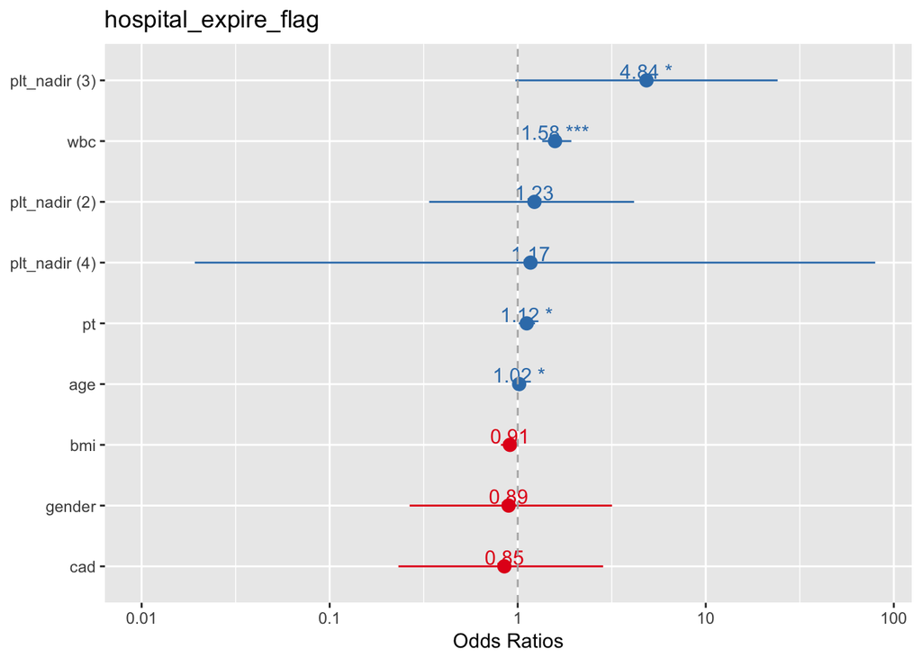

```r
sjp.glm(mdl, sort.est=T)
```

```r
# using features empirically important
mdl <- glm(hospital_expire_flag ~ (age+gender+sofa+elixhauser_vanwalraven+plt_nadir),
           data=basic[!is.na(basic$plt_nadir), ],
           family='binomial')
summary(mdl)
```

```
##
## Call:
## glm(formula = hospital_expire_flag ~ (age + gender + sofa + elixhauser_vanwalraven +
##     plt_nadir), family = "binomial", data = basic[!is.na(basic$plt_nadir),
##     ])
##
## Deviance Residuals:
##     Min       1Q   Median       3Q      Max
## -1.9900  -0.5001  -0.3609  -0.2391   2.4161
##
## Coefficients:
##                         Estimate Std. Error z value Pr(>|z|)
## (Intercept)            -4.676845   0.831805  -5.623 1.88e-08 ***
## age                     0.013091   0.004744   2.760 0.005788 **
## genderM                 0.005216   0.475190   0.011 0.991243
## sofa                    0.155701   0.067779   2.297 0.021607 *
## elixhauser_vanwalraven  0.125276   0.035984   3.481 0.000499 ***
## plt_nadir2              0.291424   0.517189   0.563 0.573111
## plt_nadir3              1.577499   0.608823   2.591 0.009568 **
## plt_nadir4              2.206843   1.458694   1.513 0.130308
## ---
## Signif. codes:  0 '***' 0.001 '**' 0.01 '*' 0.05 '.' 0.1 ' ' 1
##
## (Dispersion parameter for binomial family taken to be 1)
##
##     Null deviance: 186.54  on 194  degrees of freedom
## Residual deviance: 139.01  on 187  degrees of freedom
## AIC: 155.01
##
## Number of Fisher Scoring iterations: 5
```

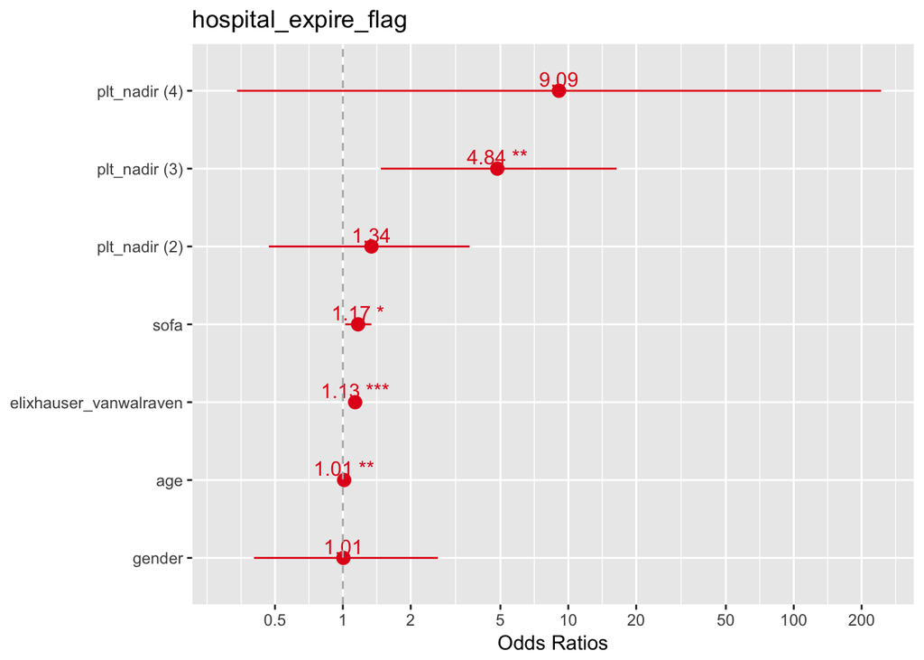

```r
sjp.glm(mdl, sort.est=T)
```

```r
# using LASSO to preselect features
X <- model.matrix(hospital_expire_flag~gender+age+bmi+sofa+elixhauser_vanwalraven+plt_minvalue+plt+ckmb+hct+rbc+hb+cre+pt+ptt+wbc+neutrophil+tempc+bivalirudin+heparin+asprin+lmwh+glycoprotein+adp+thrombolytic+cad+stroke+hemorrhage+thrombosis+congestive_heart_failure+peripheral_vascular+plt_nadir, data = basic)
y <- basic[, 9] # 9 for hosp mort, 41 for m30
mdl <- cv.glmnet(X, y, family = "binomial", alpha = 1)
coef(mdl, s=mdl$lambda.1se)
```

```
## 35 x 1 sparse Matrix of class "dgCMatrix"
##                                    1
## (Intercept)              -4.47350513
## (Intercept)               .
## genderM                   .
## age                       .
## bmi                       .
## sofa                      .
## elixhauser_vanwalraven    0.02367718
## plt_minvalue              .
## plt                       .
## ckmb                      .
## hct                       .
## rbc                       .
## hb                        .
## cre                       0.13305299
## pt                        .
## ptt                       0.01116881
## wbc                       0.17450251
## neutrophil                .
## tempc                     .
## bivalirudin               .
## heparin                   .
## asprin                    .
## lmwh                      .
## glycoprotein              .
## adp                       .
## thrombolytic              .
## cad                       .
## stroke                    .
## hemorrhage                .
## thrombosis                .
## congestive_heart_failure  .
## peripheral_vascular       .
## plt_nadir2                .
## plt_nadir3                .
## plt_nadir4                .
```

```r
mdl <- glm(m30 ~ (elixhauser_vanwalraven+cre+ptt+wbc+plt_nadir),
           data=basic[!is.na(basic$plt_nadir), ],
           family='binomial')
summary(mdl)
```

```
##
## Call:
## glm(formula = m30 ~ (elixhauser_vanwalraven + cre + ptt + wbc +
##     plt_nadir), family = "binomial", data = basic[!is.na(basic$plt_nadir),
##     ])
##
## Deviance Residuals:
##      Min        1Q    Median        3Q       Max
## -2.18321  -0.33798  -0.19826  -0.09658   2.78413
##
## Coefficients:
##                        Estimate Std. Error z value Pr(>|z|)
## (Intercept)            -9.49314    1.43845  -6.600 4.12e-11 ***
## elixhauser_vanwalraven  0.06896    0.05116   1.348  0.17766
## cre                     0.59392    0.20832   2.851  0.00436 **
## ptt                     0.03900    0.01188   3.283  0.00103 **
## wbc                     0.39167    0.08451   4.634 3.58e-06 ***
## plt_nadir2             -0.56497    0.74490  -0.758  0.44818
## plt_nadir3              0.38172    0.83184   0.459  0.64632
## plt_nadir4              1.16273    1.56773   0.742  0.45829
## ---
## Signif. codes:  0 '***' 0.001 '**' 0.01 '*' 0.05 '.' 0.1 ' ' 1
##
## (Dispersion parameter for binomial family taken to be 1)
##
##     Null deviance: 192.352  on 194  degrees of freedom
## Residual deviance:  89.069  on 187  degrees of freedom
## AIC: 105.07
##
## Number of Fisher Scoring iterations: 6
```

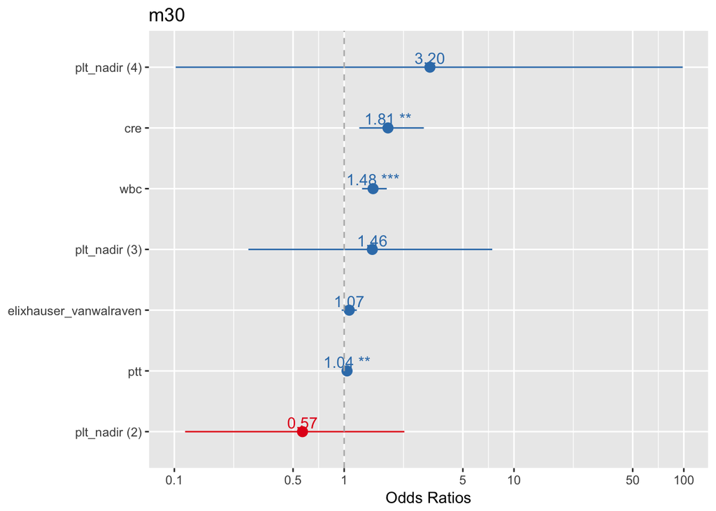

```r
sjp.glm(mdl, sort.est=T)
```

# Modeling: 30-day mortality as the outcome variable (drop)

Similar idea to above section.

```r
# using features with smaller p-value between groups
mdl <- glm(m30 ~ (age+gender+bmi+cad+pt+wbc+plt_drop_grp),
           data=basic[!is.na(basic$plt_drop_grp), ],
           family='binomial')
summary(mdl)
```

```
##
## Call:
## glm(formula = m30 ~ (age + gender + bmi + cad + pt + wbc + plt_drop_grp),
##     family = "binomial", data = basic[!is.na(basic$plt_drop_grp),
##         ])
##
## Deviance Residuals:
##      Min        1Q    Median        3Q       Max
## -1.59872  -0.43757  -0.24497  -0.09002   2.39060
##
## Coefficients:
##                Estimate Std. Error z value Pr(>|z|)
## (Intercept)   -9.536424   2.648879  -3.600 0.000318 ***
## age            0.016676   0.007229   2.307 0.021056 *
## genderM        0.035934   0.609719   0.059 0.953004
## bmi           -0.091823   0.051960  -1.767 0.077199 .
## cad           -0.004798   0.576581  -0.008 0.993361
## pt             0.117261   0.047052   2.492 0.012698 *
## wbc            0.463657   0.086210   5.378 7.52e-08 ***
## plt_drop_grp2  1.286254   1.452812   0.885 0.375965
## plt_drop_grp3  1.519270   1.406685   1.080 0.280126
## plt_drop_grp4  1.681528   1.421597   1.183 0.236871
## plt_drop_grp5  1.158708   1.662855   0.697 0.485917
## ---
## Signif. codes:  0 '***' 0.001 '**' 0.01 '*' 0.05 '.' 0.1 ' ' 1
##
## (Dispersion parameter for binomial family taken to be 1)
##
##     Null deviance: 192.35  on 194  degrees of freedom
## Residual deviance: 100.66  on 184  degrees of freedom
## AIC: 122.66
##
## Number of Fisher Scoring iterations: 6
```

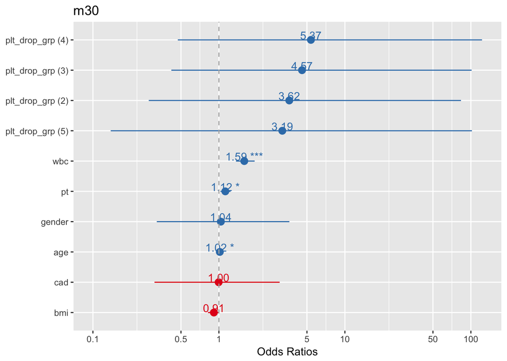

```r
sjp.glm(mdl, sort.est=T)
```

```r
# using features empirically important
mdl <- glm(m30 ~ (age+gender+sofa+elixhauser_vanwalraven+plt_drop_grp),
           data=basic[!is.na(basic$plt_drop_grp), ],
           family='binomial')
summary(mdl)
```

```
##
## Call:
## glm(formula = m30 ~ (age + gender + sofa + elixhauser_vanwalraven +
##     plt_drop_grp), family = "binomial", data = basic[!is.na(basic$plt_drop_grp),
##     ])
##
## Deviance Residuals:
##     Min       1Q   Median       3Q      Max
## -1.6036  -0.5821  -0.3970  -0.2606   2.4462
##
## Coefficients:
##                         Estimate Std. Error z value Pr(>|z|)
## (Intercept)            -4.181250   0.967384  -4.322 1.54e-05 ***
## age                     0.013378   0.004966   2.694  0.00706 **
## genderM                -0.012534   0.440655  -0.028  0.97731
## sofa                    0.189786   0.064162   2.958  0.00310 **
## elixhauser_vanwalraven  0.089019   0.032807   2.713  0.00666 **
## plt_drop_grp2          -0.572271   0.845374  -0.677  0.49844
## plt_drop_grp3          -0.306148   0.725614  -0.422  0.67309
## plt_drop_grp4           0.494513   0.748191   0.661  0.50865
## plt_drop_grp5           1.069857   0.918696   1.165  0.24421
## ---
## Signif. codes:  0 '***' 0.001 '**' 0.01 '*' 0.05 '.' 0.1 ' ' 1
##
## (Dispersion parameter for binomial family taken to be 1)
##
##     Null deviance: 192.35  on 194  degrees of freedom
## Residual deviance: 154.15  on 186  degrees of freedom
## AIC: 172.15
##
## Number of Fisher Scoring iterations: 5
```

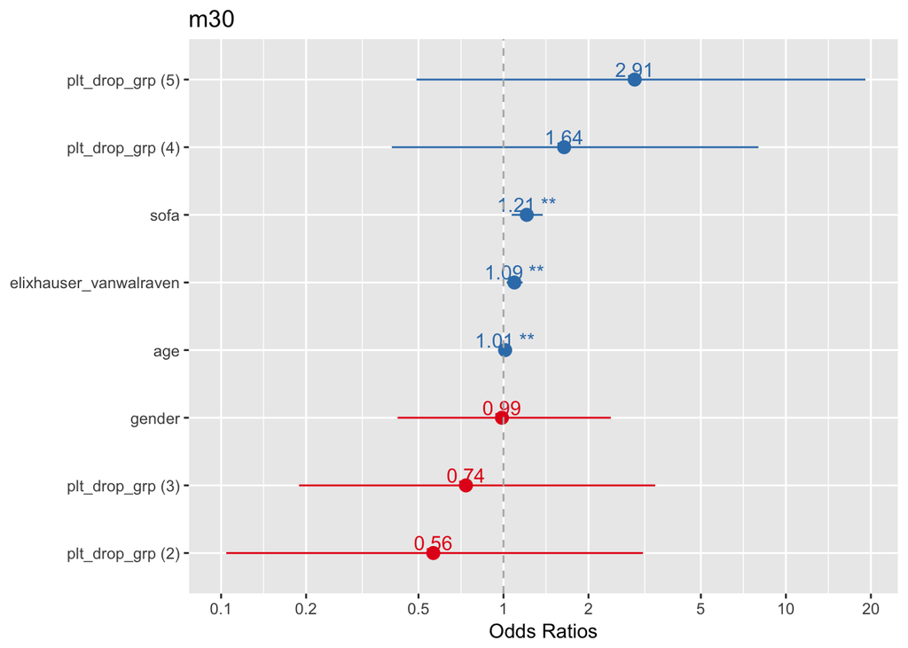

```r
sjp.glm(mdl, sort.est=T)
```

```r
# using LASSO to preselect features
X <- model.matrix(m30~gender+age+bmi+sofa+elixhauser_vanwalraven+plt_minvalue+plt+ckmb+hct+rbc+hb+cre+pt+ptt+wbc+neutrophil+tempc+bivalirudin+heparin+asprin+lmwh+glycoprotein+adp+thrombolytic+cad+stroke+hemorrhage+thrombosis+congestive_heart_failure+peripheral_vascular+plt_drop_grp, data = basic)
y <- basic[, 41] # 9 for hosp mort, 41 for m30
mdl <- cv.glmnet(X, y, family = "binomial", alpha = 1)
coef(mdl, s=mdl$lambda.1se)
```

```
## 36 x 1 sparse Matrix of class "dgCMatrix"
##                                     1
## (Intercept)              -3.910879876
## (Intercept)               .
## genderM                   .
## age                       .
## bmi                       .
## sofa                      .
## elixhauser_vanwalraven    .
## plt_minvalue              .
## plt                       .
## ckmb                      .
## hct                       .
## rbc                       .
## hb                        .
## cre                       0.119019897
## pt                        .
## ptt                       0.009235396
## wbc                       0.156024306
## neutrophil                .
## tempc                     .
## bivalirudin               .
## heparin                   .
## asprin                    .
## lmwh                      .
## glycoprotein              .
## adp                       .
## thrombolytic              .
## cad                       .
## stroke                    .
## hemorrhage                .
## thrombosis                .
## congestive_heart_failure  .
## peripheral_vascular       .
## plt_drop_grp2             .
## plt_drop_grp3             .
## plt_drop_grp4             .
## plt_drop_grp5             .
```

```r
mdl <- glm(m30 ~ (cre+ptt+wbc+plt_drop_grp),
           data=basic[!is.na(basic$plt_drop_grp), ],
           family='binomial')
summary(mdl)
```

```
##
## Call:
## glm(formula = m30 ~ (cre + ptt + wbc + plt_drop_grp), family = "binomial",
##     data = basic[!is.na(basic$plt_drop_grp), ])
##
## Deviance Residuals:
##     Min       1Q   Median       3Q      Max
## -1.7816  -0.3494  -0.1945  -0.0876   2.8710
##
## Coefficients:
##                Estimate Std. Error z value Pr(>|z|)
## (Intercept)   -10.69840    1.95102  -5.483 4.17e-08 ***
## cre             0.71644    0.20684   3.464 0.000533 ***
## ptt             0.04394    0.01214   3.619 0.000295 ***
## wbc             0.41032    0.08656   4.740 2.13e-06 ***
## plt_drop_grp2   1.28796    1.26340   1.019 0.307994
## plt_drop_grp3   0.53126    1.17136   0.454 0.650160
## plt_drop_grp4   1.41177    1.21068   1.166 0.243574
## plt_drop_grp5   1.21955    1.53465   0.795 0.426804
## ---
## Signif. codes:  0 '***' 0.001 '**' 0.01 '*' 0.05 '.' 0.1 ' ' 1
##
## (Dispersion parameter for binomial family taken to be 1)
##
##     Null deviance: 192.352  on 194  degrees of freedom
## Residual deviance:  89.952  on 187  degrees of freedom
## AIC: 105.95
##
## Number of Fisher Scoring iterations: 6
```

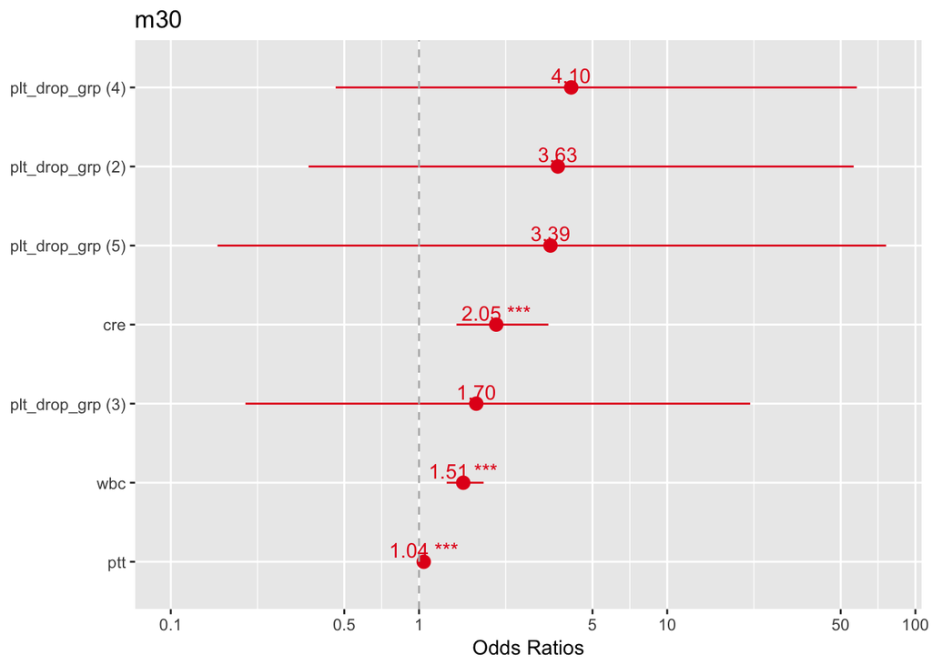

```r
sjp.glm(mdl, sort.est=T)
```

# Modeling: 30-day mortality as the outcome variable (nadir)

Again.

```r
# using features with smaller p-value between groups
mdl <- glm(m30 ~ (age+gender+bmi+cad+pt+wbc+plt_nadir),
           data=basic[!is.na(basic$plt_nadir), ],
           family='binomial')
summary(mdl)
```

```
##
## Call:
## glm(formula = m30 ~ (age + gender + bmi + cad + pt + wbc + plt_nadir),
##     family = "binomial", data = basic[!is.na(basic$plt_nadir),
##         ])
##
## Deviance Residuals:
##     Min       1Q   Median       3Q      Max
## -1.5512  -0.4449  -0.2239  -0.1003   2.4692
##
## Coefficients:
##              Estimate Std. Error z value Pr(>|z|)
## (Intercept) -7.649090   2.165846  -3.532 0.000413 ***
## age          0.016448   0.007312   2.249 0.024490 *
## genderM      0.078714   0.607026   0.130 0.896827
## bmi         -0.097569   0.051959  -1.878 0.060407 .
## cad         -0.079546   0.596223  -0.133 0.893864
## pt           0.103007   0.047564   2.166 0.030336 *
## wbc          0.457311   0.089220   5.126 2.96e-07 ***
## plt_nadir2  -0.423833   0.638417  -0.664 0.506767
## plt_nadir3   1.232688   0.792031   1.556 0.119622
## plt_nadir4  -0.100266   2.044742  -0.049 0.960891
## ---
## Signif. codes:  0 '***' 0.001 '**' 0.01 '*' 0.05 '.' 0.1 ' ' 1
##
## (Dispersion parameter for binomial family taken to be 1)
##
##     Null deviance: 192.352  on 194  degrees of freedom
## Residual deviance:  98.967  on 185  degrees of freedom
## AIC: 118.97
##
## Number of Fisher Scoring iterations: 6
```

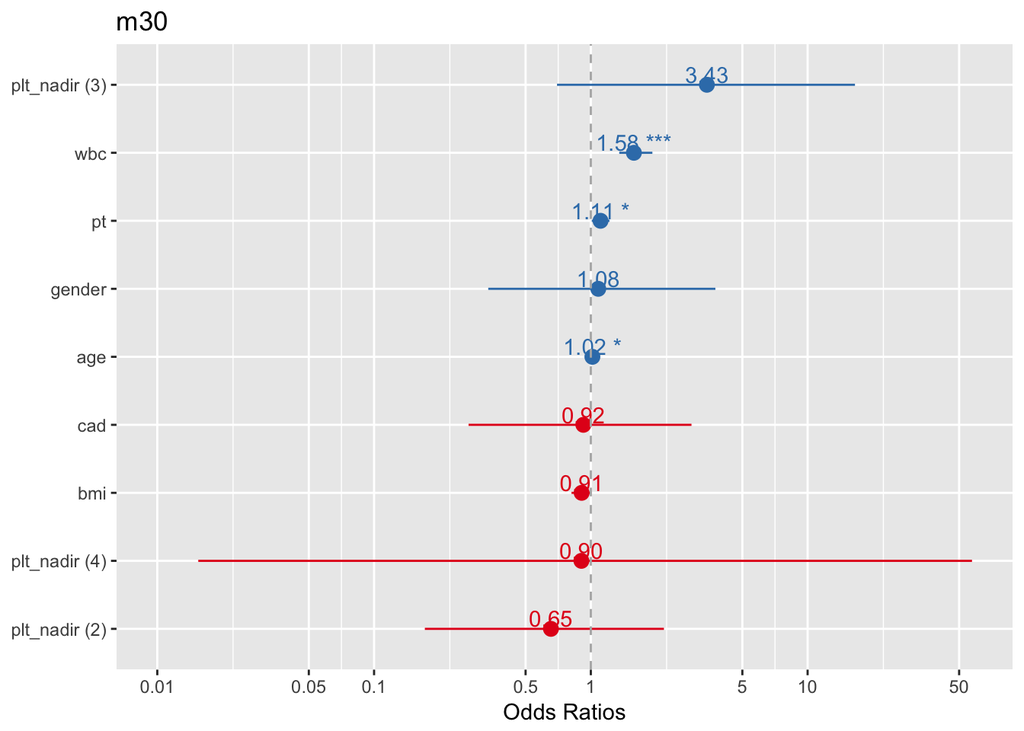

```r
sjp.glm(mdl, sort.est=T)
```

```r
# using features empirically important
mdl <- glm(m30 ~ (age+gender+sofa+elixhauser_vanwalraven+plt_nadir),
           data=basic[!is.na(basic$plt_nadir), ],
           family='binomial')
summary(mdl)
```

```
##
## Call:
## glm(formula = m30 ~ (age + gender + sofa + elixhauser_vanwalraven +
##     plt_nadir), family = "binomial", data = basic[!is.na(basic$plt_nadir),
##     ])
##
## Deviance Residuals:
##     Min       1Q   Median       3Q      Max
## -1.7957  -0.5232  -0.4008  -0.2832   2.4154
##
## Coefficients:
##                         Estimate Std. Error z value Pr(>|z|)
## (Intercept)            -4.274546   0.769426  -5.556 2.77e-08 ***
## age                     0.012227   0.004726   2.587  0.00969 **
## genderM                 0.052095   0.453829   0.115  0.90861
## sofa                    0.173192   0.064948   2.667  0.00766 **
## elixhauser_vanwalraven  0.090577   0.033786   2.681  0.00734 **
## plt_nadir2             -0.058888   0.503669  -0.117  0.90693
## plt_nadir3              1.391883   0.588812   2.364  0.01808 *
## plt_nadir4              1.917328   1.449976   1.322  0.18606
## ---
## Signif. codes:  0 '***' 0.001 '**' 0.01 '*' 0.05 '.' 0.1 ' ' 1
##
## (Dispersion parameter for binomial family taken to be 1)
##
##     Null deviance: 192.35  on 194  degrees of freedom
## Residual deviance: 152.18  on 187  degrees of freedom
## AIC: 168.18
##
## Number of Fisher Scoring iterations: 5
```

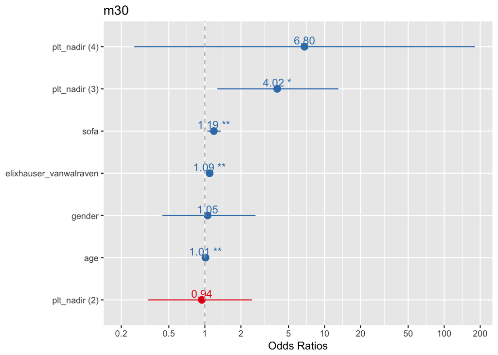

```r
sjp.glm(mdl, sort.est=T)
```

```r
# using LASSO to preselect features
X <- model.matrix(m30~gender+age+bmi+sofa+elixhauser_vanwalraven+plt_minvalue+plt+ckmb+hct+rbc+hb+cre+pt+ptt+wbc+neutrophil+tempc+bivalirudin+heparin+asprin+lmwh+glycoprotein+adp+thrombolytic+cad+stroke+hemorrhage+thrombosis+congestive_heart_failure+peripheral_vascular+plt_nadir, data = basic)
y <- basic[, 41] # 9 for hosp mort, 41 for m30
mdl <- cv.glmnet(X, y, family = "binomial", alpha = 1)
coef(mdl, s=mdl$lambda.1se)
```

```
## 35 x 1 sparse Matrix of class "dgCMatrix"
##                                     1
## (Intercept)              -3.910879876
## (Intercept)               .
## genderM                   .
## age                       .
## bmi                       .
## sofa                      .
## elixhauser_vanwalraven    .
## plt_minvalue              .
## plt                       .
## ckmb                      .
## hct                       .
## rbc                       .
## hb                        .
## cre                       0.119019897
## pt                        .
## ptt                       0.009235396
## wbc                       0.156024306
## neutrophil                .
## tempc                     .
## bivalirudin               .
## heparin                   .
## asprin                    .
## lmwh                      .
## glycoprotein              .
## adp                       .
## thrombolytic              .
## cad                       .
## stroke                    .
## hemorrhage                .
## thrombosis                .
## congestive_heart_failure  .
## peripheral_vascular       .
## plt_nadir2                .
## plt_nadir3                .
## plt_nadir4                .
```

```r
mdl <- glm(m30 ~ (cre+ptt+wbc+plt_nadir),
           data=basic[!is.na(basic$plt_nadir), ],
           family='binomial')
summary(mdl)
```

```
##
## Call:
## glm(formula = m30 ~ (cre + ptt + wbc + plt_nadir), family = "binomial",
##     data = basic[!is.na(basic$plt_nadir), ])
##
## Deviance Residuals:
##     Min       1Q   Median       3Q      Max
## -1.9214  -0.3488  -0.2129  -0.1029   2.6859
##
## Coefficients:
##             Estimate Std. Error z value Pr(>|z|)
## (Intercept) -9.33346    1.39790  -6.677 2.44e-11 ***
## cre          0.68665    0.20726   3.313 0.000923 ***
## ptt          0.03863    0.01170   3.302 0.000960 ***
## wbc          0.39863    0.08472   4.705 2.54e-06 ***
## plt_nadir2  -0.46722    0.71738  -0.651 0.514868
## plt_nadir3   0.63566    0.84253   0.754 0.450574
## plt_nadir4   1.09515    1.55955   0.702 0.482541
## ---
## Signif. codes:  0 '***' 0.001 '**' 0.01 '*' 0.05 '.' 0.1 ' ' 1
##
## (Dispersion parameter for binomial family taken to be 1)
##
##     Null deviance: 192.352  on 194  degrees of freedom
## Residual deviance:  90.841  on 188  degrees of freedom
## AIC: 104.84
##
## Number of Fisher Scoring iterations: 6
```

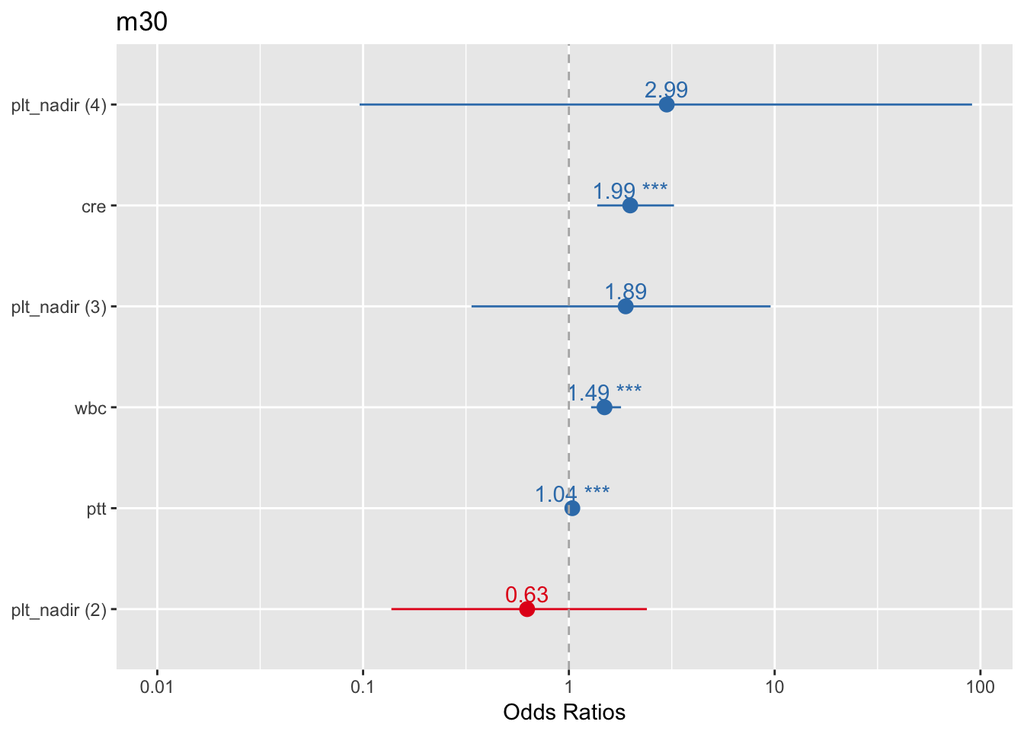

```r
sjp.glm(mdl, sort.est=T)
```

# Modeling: use IABP time, hospital/ICU LOS as outcome variables (drop)

Since these variables are continuous, we just linear regression to fit the data.

```r
lmdl <- lm(iabp_time/60 ~ (gender+age+bmi+cad+pt+wbc+plt_drop_grp),
           data=basic[!is.na(basic$plt_drop_grp), ])
summary(lmdl)
```

```
##
## Call:
## lm(formula = iabp_time/60 ~ (gender + age + bmi + cad + pt +
##     wbc + plt_drop_grp), data = basic[!is.na(basic$plt_drop_grp),
##     ])
##
## Residuals:
##     Min      1Q  Median      3Q     Max
## -46.963 -18.740  -7.733  10.440 238.356
##
## Coefficients:
##               Estimate Std. Error t value Pr(>|t|)
## (Intercept)   13.74876   15.43684   0.891  0.37428
## genderM       -4.98367    5.62769  -0.886  0.37701
## age           -0.03942    0.07384  -0.534  0.59411
## bmi            0.06280    0.21178   0.297  0.76715
## cad           -5.64048    5.40497  -1.044  0.29805
## pt             0.13168    0.28987   0.454  0.65016
## wbc            0.80983    0.58752   1.378  0.16976
## plt_drop_grp2 14.06405    9.75211   1.442  0.15096
## plt_drop_grp3 25.74756    8.88613   2.898  0.00422 **
## plt_drop_grp4 25.32033    9.74595   2.598  0.01014 *
## plt_drop_grp5 23.28954   13.58980   1.714  0.08826 .
## ---
## Signif. codes:  0 '***' 0.001 '**' 0.01 '*' 0.05 '.' 0.1 ' ' 1
##
## Residual standard error: 34.8 on 184 degrees of freedom
## Multiple R-squared:  0.09716,    Adjusted R-squared:  0.04809
## F-statistic:  1.98 on 10 and 184 DF,  p-value: 0.03768
```

```r
lmdl <- lm(los_hospital ~ (gender+age+bmi+cad+pt+wbc+plt_drop_grp),
           data=basic[!is.na(basic$plt_drop_grp), ])
summary(lmdl)
```

```
##
## Call:
## lm(formula = los_hospital ~ (gender + age + bmi + cad + pt +
##     wbc + plt_drop_grp), data = basic[!is.na(basic$plt_drop_grp),
##     ])
##
## Residuals:
##     Min      1Q  Median      3Q     Max
## -12.513  -5.545  -2.285   2.626  54.499
##
## Coefficients:
##               Estimate Std. Error t value Pr(>|t|)
## (Intercept)   14.24122    4.24122   3.358 0.000955 ***
## genderM       -2.44352    1.54619  -1.580 0.115744
## age           -0.02536    0.02029  -1.250 0.212790
## bmi            0.01079    0.05818   0.185 0.853090
## cad           -0.15127    1.48500  -0.102 0.918972
## pt             0.01408    0.07964   0.177 0.859821
## wbc           -0.35790    0.16142  -2.217 0.027832 *
## plt_drop_grp2  0.87874    2.67936   0.328 0.743309
## plt_drop_grp3  5.96972    2.44143   2.445 0.015420 *
## plt_drop_grp4  5.96745    2.67767   2.229 0.027051 *
## plt_drop_grp5  9.98933    3.73375   2.675 0.008137 **
## ---
## Signif. codes:  0 '***' 0.001 '**' 0.01 '*' 0.05 '.' 0.1 ' ' 1
##
## Residual standard error: 9.561 on 184 degrees of freedom
## Multiple R-squared:  0.1263, Adjusted R-squared:  0.07878
## F-statistic: 2.659 on 10 and 184 DF,  p-value: 0.004692
```

```r
lmdl <- lm(los_icu ~ (gender+age+bmi+cad+pt+wbc+plt_drop_grp),
           data=basic[!is.na(basic$plt_drop_grp), ])
summary(lmdl)
```

```
##
## Call:
## lm(formula = los_icu ~ (gender + age + bmi + cad + pt + wbc +
##     plt_drop_grp), data = basic[!is.na(basic$plt_drop_grp), ])
##
## Residuals:
##     Min      1Q  Median      3Q     Max
## -11.026  -4.348  -2.135   1.011  42.087
##
## Coefficients:
##                Estimate Std. Error t value Pr(>|t|)
## (Intercept)    6.079545   3.572821   1.702   0.0905 .
## genderM       -1.912270   1.302516  -1.468   0.1438
## age           -0.007968   0.017089  -0.466   0.6416
## bmi            0.018030   0.049015   0.368   0.7134
## cad           -1.605789   1.250967  -1.284   0.2009
## pt            -0.004764   0.067089  -0.071   0.9435
## wbc            0.004886   0.135981   0.036   0.9714
## plt_drop_grp2  1.301453   2.257104   0.577   0.5649
## plt_drop_grp3  4.444197   2.056673   2.161   0.0320 *
## plt_drop_grp4  4.888048   2.255678   2.167   0.0315 *
## plt_drop_grp5  8.084476   3.145328   2.570   0.0110 *
## ---
## Signif. codes:  0 '***' 0.001 '**' 0.01 '*' 0.05 '.' 0.1 ' ' 1
##
## Residual standard error: 8.055 on 184 degrees of freedom
## Multiple R-squared:  0.1054, Adjusted R-squared:  0.05676
## F-statistic: 2.167 on 10 and 184 DF,  p-value: 0.02159
```

# Modeling: use IABP time, hospital/ICU LOS as outcome variables (nadir)

Try again using platelet nadir.

```r
lmdl <- lm(iabp_time/60 ~ (gender+age+bmi+cad+pt+wbc+plt_nadir),
           data=basic[!is.na(basic$plt_nadir), ])
summary(lmdl)
```

```
##
## Call:
## lm(formula = iabp_time/60 ~ (gender + age + bmi + cad + pt +
##     wbc + plt_nadir), data = basic[!is.na(basic$plt_nadir), ])
##
## Residuals:
##     Min      1Q  Median      3Q     Max
## -52.222 -19.322  -8.101  10.981 241.228
##
## Coefficients:
##             Estimate Std. Error t value Pr(>|t|)
## (Intercept) 40.15431   12.25717   3.276  0.00126 **
## genderM     -4.31800    5.72968  -0.754  0.45204
## age         -0.07025    0.07385  -0.951  0.34267
## bmi         -0.02617    0.21155  -0.124  0.90170
## cad         -7.23306    5.46173  -1.324  0.18703
## pt           0.02129    0.29230   0.073  0.94201
## wbc          0.60912    0.59332   1.027  0.30594
## plt_nadir2   5.19972    5.87476   0.885  0.37725
## plt_nadir3  16.12783    9.23554   1.746  0.08242 .
## plt_nadir4  22.91876   25.46482   0.900  0.36928
## ---
## Signif. codes:  0 '***' 0.001 '**' 0.01 '*' 0.05 '.' 0.1 ' ' 1
##
## Residual standard error: 35.32 on 185 degrees of freedom
## Multiple R-squared:  0.06499,    Adjusted R-squared:  0.0195
## F-statistic: 1.429 on 9 and 185 DF,  p-value: 0.1784
```

```r
lmdl <- lm(los_hospital ~ (gender+age+bmi+cad+pt+wbc+plt_nadir),
           data=basic[!is.na(basic$plt_nadir), ])
summary(lmdl)
```

```
##
## Call:
## lm(formula = los_hospital ~ (gender + age + bmi + cad + pt +
##     wbc + plt_nadir), data = basic[!is.na(basic$plt_nadir), ])
##
## Residuals:
##     Min      1Q  Median      3Q     Max
## -14.535  -5.155  -2.455   2.428  52.663
##
## Coefficients:
##              Estimate Std. Error t value Pr(>|t|)
## (Intercept) 18.877977   3.291188   5.736  3.9e-08 ***
## genderM     -2.398549   1.538483  -1.559  0.12070
## age         -0.038632   0.019829  -1.948  0.05289 .
## bmi          0.001915   0.056805   0.034  0.97314
## cad         -0.676145   1.466536  -0.461  0.64530
## pt          -0.010165   0.078485  -0.130  0.89709
## wbc         -0.404369   0.159314  -2.538  0.01197 *
## plt_nadir2   5.037241   1.577440   3.193  0.00165 **
## plt_nadir3   7.257420   2.479848   2.927  0.00386 **
## plt_nadir4  13.092127   6.837592   1.915  0.05707 .
## ---
## Signif. codes:  0 '***' 0.001 '**' 0.01 '*' 0.05 '.' 0.1 ' ' 1
##
## Residual standard error: 9.484 on 185 degrees of freedom
## Multiple R-squared:  0.1357, Adjusted R-squared:  0.09369
## F-statistic: 3.228 on 9 and 185 DF,  p-value: 0.001161
```

```r
lmdl <- lm(los_icu ~ (gender+age+bmi+cad+pt+wbc+plt_nadir),
           data=basic[!is.na(basic$plt_nadir), ])
summary(lmdl)
```

```
##
## Call:
## lm(formula = los_icu ~ (gender + age + bmi + cad + pt + wbc +
##     plt_nadir), data = basic[!is.na(basic$plt_nadir), ])
##
## Residuals:
##     Min      1Q  Median      3Q     Max
## -12.810  -4.304  -2.013   0.767  44.081
##
## Coefficients:
##              Estimate Std. Error t value Pr(>|t|)
## (Intercept) 10.203501   2.764470   3.691 0.000294 ***
## genderM     -1.724515   1.292266  -1.334 0.183684
## age         -0.016815   0.016655  -1.010 0.314003
## bmi          0.005712   0.047714   0.120 0.904841
## cad         -1.973835   1.231834  -1.602 0.110783
## pt          -0.027398   0.065925  -0.416 0.678184
## wbc         -0.038643   0.133818  -0.289 0.773078
## plt_nadir2   2.395718   1.324988   1.808 0.072214 .
## plt_nadir3   6.153515   2.082976   2.954 0.003542 **
## plt_nadir4  14.291643   5.743313   2.488 0.013716 *
## ---
## Signif. codes:  0 '***' 0.001 '**' 0.01 '*' 0.05 '.' 0.1 ' ' 1
##
## Residual standard error: 7.966 on 185 degrees of freedom
## Multiple R-squared:  0.1202, Adjusted R-squared:  0.0774
## F-statistic: 2.808 on 9 and 185 DF,  p-value: 0.004096
```

# Modeling: predictive analytics (drop)

In the last part, we wanted to see if the selected features are useful for prediction. To be interpretable, we simply selected decision tree.

```r
# prediction model
set.seed(88)
t <- createDataPartition(basic$hospital_expire_flag, p = 0.7, list=FALSE)
training <- basic[t, ]
test <- basic[t, ]

model <- rpart(hospital_expire_flag ~ (gender+age+bmi+cad+sofa+elixhauser_vanwalraven+plt_drop_grp), training, method="class")
pred <- predict(model, test[, c("gender", "age", "bmi", "cad", "sofa", "elixhauser_vanwalraven", "plt_drop_grp")], type="class")
confusionMatrix(pred, test[, "hospital_expire_flag"])
```

```
## Confusion Matrix and Statistics
##
##           Reference
## Prediction   0   1
##          0 102   9
##          1  10  16
##
##                Accuracy : 0.8613
##                  95% CI : (0.7919, 0.9144)
##     No Information Rate : 0.8175
##     P-Value [Acc > NIR] : 0.1093
##
##                   Kappa : 0.5423
##  Mcnemar's Test P-Value : 1.0000
##
##             Sensitivity : 0.9107
##             Specificity : 0.6400
##          Pos Pred Value : 0.9189
##          Neg Pred Value : 0.6154
##              Prevalence : 0.8175
##          Detection Rate : 0.7445
##    Detection Prevalence : 0.8102
##       Balanced Accuracy : 0.7754
##
##        'Positive' Class : 0
##
```

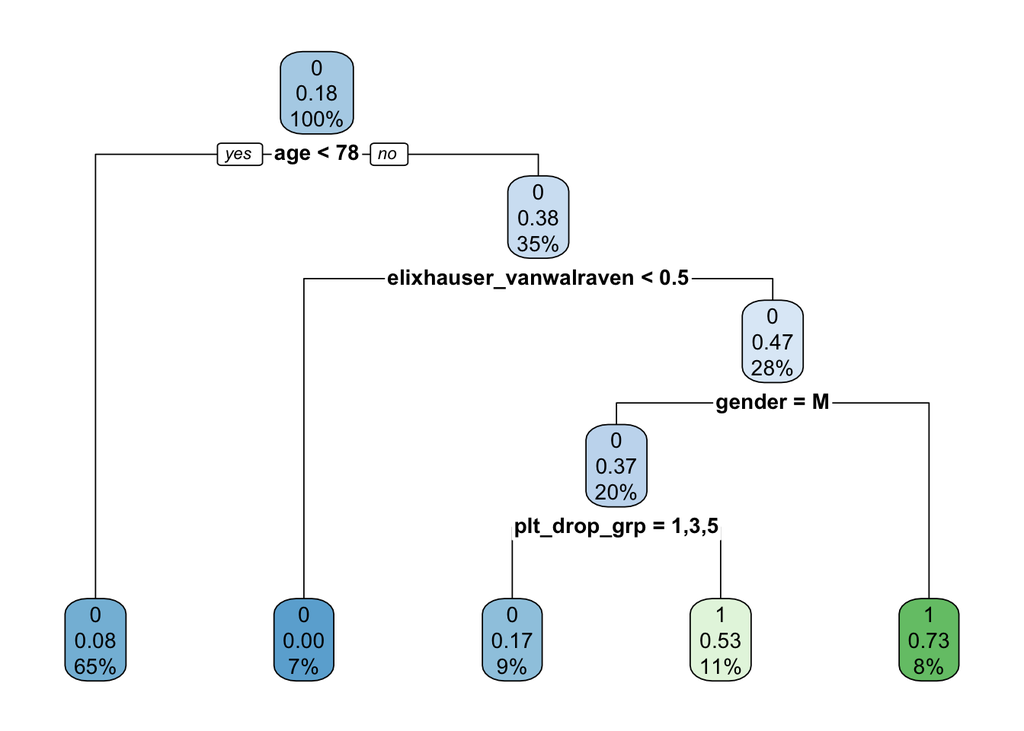

```r
rpart.plot(model)
```

```r
model <- rpart(m30 ~ (gender+age+bmi+cad+sofa+elixhauser_vanwalraven+plt_drop_grp), training, method="class")
pred <- predict(model, test[, c("gender", "age", "bmi", "cad", "sofa", "elixhauser_vanwalraven", "plt_drop_grp")], type="class")
confusionMatrix(pred, test[, "m30"])
```

```
## Confusion Matrix and Statistics
##
##           Reference
## Prediction   0   1
##          0 107  15
##          1   4  11
##
##                Accuracy : 0.8613
##                  95% CI : (0.7919, 0.9144)
##     No Information Rate : 0.8102
##     P-Value [Acc > NIR] : 0.07449
##
##                   Kappa : 0.4619
##  Mcnemar's Test P-Value : 0.02178
##
##             Sensitivity : 0.9640
##             Specificity : 0.4231
##          Pos Pred Value : 0.8770
##          Neg Pred Value : 0.7333
##              Prevalence : 0.8102
##          Detection Rate : 0.7810
##    Detection Prevalence : 0.8905
##       Balanced Accuracy : 0.6935
##
##        'Positive' Class : 0
##
```

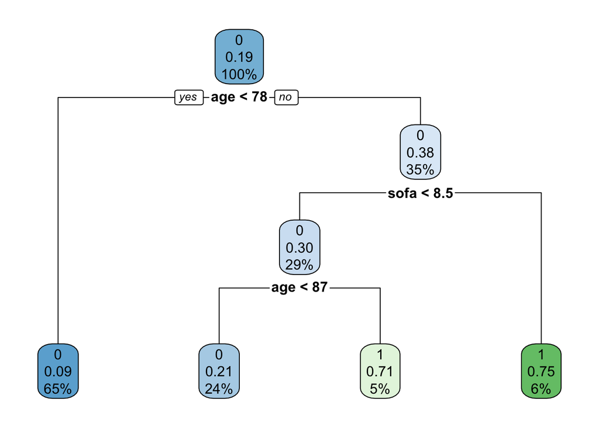

```r
rpart.plot(model)
```

# Modeling: predictive analytics (nadir)

In the last part, we wanted to see if the selected features are useful for prediction. To be interpretable, we simply selected decision tree.

```r
# prediction model
set.seed(88)
t <- createDataPartition(basic$hospital_expire_flag, p = 0.7, list=FALSE)
training <- basic[t, ]
test <- basic[t, ]

model <- rpart(hospital_expire_flag ~ (gender+age+bmi+cad+sofa+elixhauser_vanwalraven+plt_nadir), training, method="class")
pred <- predict(model, test[, c("gender", "age", "bmi", "cad", "sofa", "elixhauser_vanwalraven", "plt_nadir")], type="class")
confusionMatrix(pred, test[, "hospital_expire_flag"])
```

```
## Confusion Matrix and Statistics
##
##           Reference
## Prediction   0   1
##          0 107  15
##          1   5  10
##
##                Accuracy : 0.854
##                  95% CI : (0.7836, 0.9085)
##     No Information Rate : 0.8175
##     P-Value [Acc > NIR] : 0.15964
##
##                   Kappa : 0.4207
##  Mcnemar's Test P-Value : 0.04417
##
##             Sensitivity : 0.9554
##             Specificity : 0.4000
##          Pos Pred Value : 0.8770
##          Neg Pred Value : 0.6667
##              Prevalence : 0.8175
##          Detection Rate : 0.7810
##    Detection Prevalence : 0.8905
##       Balanced Accuracy : 0.6777
##
##        'Positive' Class : 0
##
```

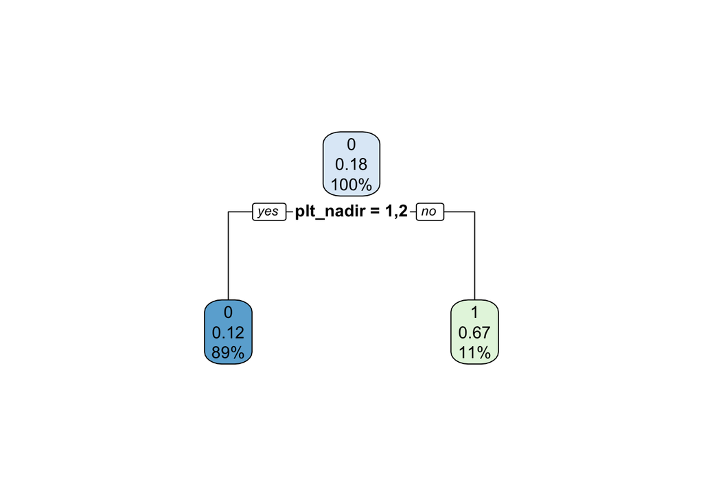

```r
rpart.plot(model)
```

```r
model <- rpart(m30 ~ (gender+age+bmi+cad+sofa+elixhauser_vanwalraven+plt_nadir), training, method="class")
pred <- predict(model, test[, c("gender", "age", "bmi", "cad", "sofa", "elixhauser_vanwalraven", "plt_nadir")], type="class")
confusionMatrix(pred, test[, "m30"])
```

```
## Confusion Matrix and Statistics
##
##           Reference
## Prediction   0   1
##          0 104  11
##          1   7  15
##
##                Accuracy : 0.8686
##                  95% CI : (0.8003, 0.9202)
##     No Information Rate : 0.8102
##     P-Value [Acc > NIR] : 0.04655
##
##                   Kappa : 0.546
##  Mcnemar's Test P-Value : 0.47950
##
##             Sensitivity : 0.9369
##             Specificity : 0.5769
##          Pos Pred Value : 0.9043
##          Neg Pred Value : 0.6818
##              Prevalence : 0.8102
##          Detection Rate : 0.7591
##    Detection Prevalence : 0.8394
##       Balanced Accuracy : 0.7569
##
##        'Positive' Class : 0
##
```

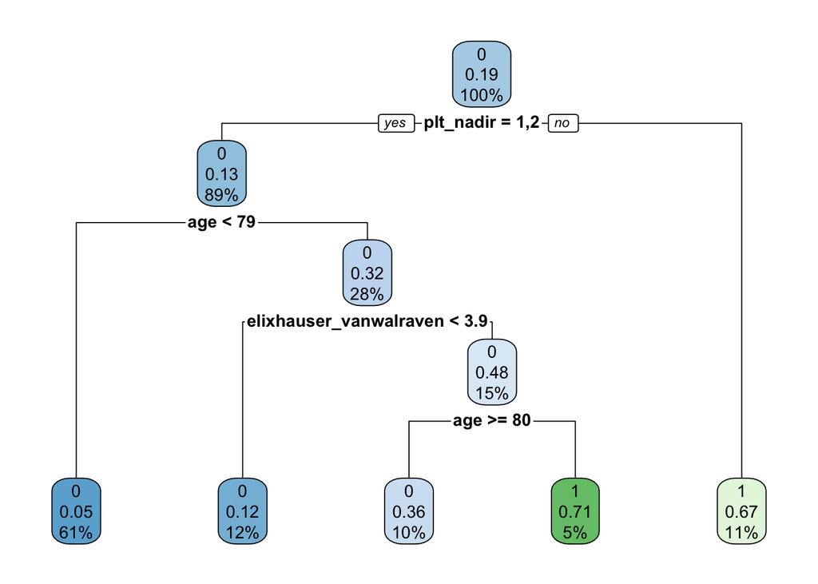

```r
rpart.plot(model)
```